# Frito Lay: Customer Attrition

```r
library(tidyverse)
library(caret)
library(e1071)
library(class)
library(ggthemes)
```

# ———— Data Loading ————-

```r
getwd()
```

```
## [1] "/Users/cory/Projects/DDSAnalytics_customer_attrition"
```

```r
data <- read.csv("CaseStudy1-data.csv")
```

# ———— Data Quality, Structure & Sanity Checks ————-

```r
# Data Dimensionality
dim(data)
```

```
## [1] 870  36
```

```r
# Missing Values
sum(is.na(data))
```

```
## [1] 0
```

```r
str(data)
```

```
## 'data.frame':    870 obs. of  36 variables:
##  $ ID                      : int  1 2 3 4 5 6 7 8 9 10 ...
##  $ Age                     : int  32 40 35 32 24 27 41 37 34 34 ...
##  $ Attrition               : chr  "No" "No" "No" "No" ...
##  $ BusinessTravel          : chr  "Travel_Rarely" "Travel_Rarely" "Travel_Frequently" "Travel_Rarely" ...
##  $ DailyRate               : int  117 1308 200 801 567 294 1283 309 1333 653 ...
##  $ Department              : chr  "Sales" "Research & Development" "Research & Development" "Sales" ...
##  $ DistanceFromHome        : int  13 14 18 1 2 10 5 10 10 10 ...
##  $ Education               : int  4 3 2 4 1 2 5 4 4 4 ...
##  $ EducationField          : chr  "Life Sciences" "Medical" "Life Sciences" "Marketing" ...
##  $ EmployeeCount           : int  1 1 1 1 1 1 1 1 1 1 ...
##  $ EmployeeNumber          : int  859 1128 1412 2016 1646 733 1448 1105 1055 1597 ...
##  $ EnvironmentSatisfaction : int  2 3 3 3 1 4 2 4 3 4 ...
##  $ Gender                  : chr  "Male" "Male" "Male" "Female" ...
##  $ HourlyRate              : int  73 44 60 48 32 32 90 88 87 92 ...
```

[output cut: 22 more lines]

```r
# Summary statistics
summary(data)
```

```
##        ID             Age         Attrition         BusinessTravel
##  Min.   :  1.0   Min.   :18.00   Length:870         Length:870
##  1st Qu.:218.2   1st Qu.:30.00   Class :character   Class :character
##  Median :435.5   Median :35.00   Mode  :character   Mode  :character
##  Mean   :435.5   Mean   :36.83
##  3rd Qu.:652.8   3rd Qu.:43.00
##  Max.   :870.0   Max.   :60.00
##    DailyRate       Department        DistanceFromHome   Education
##  Min.   : 103.0   Length:870         Min.   : 1.000   Min.   :1.000
##  1st Qu.: 472.5   Class :character   1st Qu.: 2.000   1st Qu.:2.000
##  Median : 817.5   Mode  :character   Median : 7.000   Median :3.000
##  Mean   : 815.2                      Mean   : 9.339   Mean   :2.901
##  3rd Qu.:1165.8                      3rd Qu.:14.000   3rd Qu.:4.000
##  Max.   :1499.0                      Max.   :29.000   Max.   :5.000
##  EducationField     EmployeeCount EmployeeNumber   EnvironmentSatisfaction
##  Length:870         Min.   :1     Min.   :   1.0   Min.   :1.000
##  Class :character   1st Qu.:1     1st Qu.: 477.2   1st Qu.:2.000
##  Mode  :character   Median :1     Median :1039.0   Median :3.000
##                     Mean   :1     Mean   :1029.8   Mean   :2.701
##                     3rd Qu.:1     3rd Qu.:1561.5   3rd Qu.:4.000
##                     Max.   :1     Max.   :2064.0   Max.   :4.000
##     Gender            HourlyRate     JobInvolvement     JobLevel
##  Length:870         Min.   : 30.00   Min.   :1.000   Min.   :1.000
##  Class :character   1st Qu.: 48.00   1st Qu.:2.000   1st Qu.:1.000
##  Mode  :character   Median : 66.00   Median :3.000   Median :2.000
##                     Mean   : 65.61   Mean   :2.723   Mean   :2.039
##                     3rd Qu.: 83.00   3rd Qu.:3.000   3rd Qu.:3.000
##                     Max.   :100.00   Max.   :4.000   Max.   :5.000
##    JobRole          JobSatisfaction MaritalStatus      MonthlyIncome
##  Length:870         Min.   :1.000   Length:870         Min.   : 1081
##  Class :character   1st Qu.:2.000   Class :character   1st Qu.: 2840
##  Mode  :character   Median :3.000   Mode  :character   Median : 4946
##                     Mean   :2.709                      Mean   : 6390
##                     3rd Qu.:4.000                      3rd Qu.: 8182
##                     Max.   :4.000                      Max.   :19999
##   MonthlyRate    NumCompaniesWorked    Over18            OverTime
##  Min.   : 2094   Min.   :0.000      Length:870         Length:870
##  1st Qu.: 8092   1st Qu.:1.000      Class :character   Class :character
##  Median :14074   Median :2.000      Mode  :character   Mode  :character
##  Mean   :14326   Mean   :2.728
```

[output cut: 15 more lines]

```
##  Max.   :3.0000   Max.   :40.00     Max.   :6.000         Max.   :4.000
##  YearsAtCompany   YearsInCurrentRole YearsSinceLastPromotion
##  Min.   : 0.000   Min.   : 0.000     Min.   : 0.000
##  1st Qu.: 3.000   1st Qu.: 2.000     1st Qu.: 0.000
##  Median : 5.000   Median : 3.000     Median : 1.000
##  Mean   : 6.962   Mean   : 4.205     Mean   : 2.169
##  3rd Qu.:10.000   3rd Qu.: 7.000     3rd Qu.: 3.000
##  Max.   :40.000   Max.   :18.000     Max.   :15.000
##  YearsWithCurrManager
##  Min.   : 0.00
##  1st Qu.: 2.00
##  Median : 3.00
##  Mean   : 4.14
##  3rd Qu.: 7.00
##  Max.   :17.00
```

```r
# Duplicate Analysis
sum(duplicated(data))
```

```
## [1] 0
```

```r
# Columns in data
colnames(data)
```

```
##  [1] "ID"                       "Age"
##  [3] "Attrition"                "BusinessTravel"
##  [5] "DailyRate"                "Department"
##  [7] "DistanceFromHome"         "Education"
##  [9] "EducationField"           "EmployeeCount"
## [11] "EmployeeNumber"           "EnvironmentSatisfaction"
## [13] "Gender"                   "HourlyRate"
## [15] "JobInvolvement"           "JobLevel"
## [17] "JobRole"                  "JobSatisfaction"
## [19] "MaritalStatus"            "MonthlyIncome"
## [21] "MonthlyRate"              "NumCompaniesWorked"
## [23] "Over18"                   "OverTime"
## [25] "PercentSalaryHike"        "PerformanceRating"
## [27] "RelationshipSatisfaction" "StandardHours"
## [29] "StockOptionLevel"         "TotalWorkingYears"
## [31] "TrainingTimesLastYear"    "WorkLifeBalance"
## [33] "YearsAtCompany"           "YearsInCurrentRole"
## [35] "YearsSinceLastPromotion"  "YearsWithCurrManager"
```

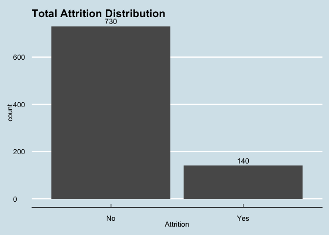

```r
#Checking out the Attrition Distribution
ggplot(data = data, mapping = aes(x = Attrition))  +
  geom_bar() +
  geom_text(
    stat = "count",
    aes(label = ..count..),
    vjust = -0.5,
    size = 4,
    color = "black"
  ) +
  theme_economist() +
  labs(
    title = "Total Attrition Distribution"
      )
```

# ————- Target Analysis —————

# Summarize the Attrition Rate

```r
# Gives me a input level breakdown of the target variable
data$Attrition
```

[output not shown]

[output cut: 58 more lines]

```r
# Creates a count table (super useful!)
table(data$Attrition)
```

```
##
##  No Yes
## 730 140
```

```r
# Gives me the proportion of each level in the target variable
prop.table(table(data$Attrition)) * 100
```

```
##
##       No      Yes
## 83.90805 16.09195
```

Frito Lays’ Attrition rate is 16.09%. This means that 16.09% of customers have churned.

```r
str(data)
```

```
## 'data.frame':    870 obs. of  36 variables:
##  $ ID                      : int  1 2 3 4 5 6 7 8 9 10 ...
##  $ Age                     : int  32 40 35 32 24 27 41 37 34 34 ...
##  $ Attrition               : chr  "No" "No" "No" "No" ...
##  $ BusinessTravel          : chr  "Travel_Rarely" "Travel_Rarely" "Travel_Frequently" "Travel_Rarely" ...
##  $ DailyRate               : int  117 1308 200 801 567 294 1283 309 1333 653 ...
##  $ Department              : chr  "Sales" "Research & Development" "Research & Development" "Sales" ...
##  $ DistanceFromHome        : int  13 14 18 1 2 10 5 10 10 10 ...
##  $ Education               : int  4 3 2 4 1 2 5 4 4 4 ...
##  $ EducationField          : chr  "Life Sciences" "Medical" "Life Sciences" "Marketing" ...
##  $ EmployeeCount           : int  1 1 1 1 1 1 1 1 1 1 ...
##  $ EmployeeNumber          : int  859 1128 1412 2016 1646 733 1448 1105 1055 1597 ...
##  $ EnvironmentSatisfaction : int  2 3 3 3 1 4 2 4 3 4 ...
##  $ Gender                  : chr  "Male" "Male" "Male" "Female" ...
##  $ HourlyRate              : int  73 44 60 48 32 32 90 88 87 92 ...
```

[output cut: 22 more lines]

```r
# Unique values in job_level
unique(data$JobLevel)
```

```
## [1] 2 5 3 1 4
```

```r
null_summary <- sapply(data, function(x) sum(is.na(x)))
null_summary
```

```
##                       ID                      Age                Attrition
##                        0                        0                        0
##           BusinessTravel                DailyRate               Department
##                        0                        0                        0
##         DistanceFromHome                Education           EducationField
##                        0                        0                        0
##            EmployeeCount           EmployeeNumber  EnvironmentSatisfaction
##                        0                        0                        0
##                   Gender               HourlyRate           JobInvolvement
##                        0                        0                        0
##                 JobLevel                  JobRole          JobSatisfaction
##                        0                        0                        0
##            MaritalStatus            MonthlyIncome              MonthlyRate
##                        0                        0                        0
##       NumCompaniesWorked                   Over18                 OverTime
##                        0                        0                        0
##        PercentSalaryHike        PerformanceRating RelationshipSatisfaction
##                        0                        0                        0
##            StandardHours         StockOptionLevel        TotalWorkingYears
##                        0                        0                        0
##    TrainingTimesLastYear          WorkLifeBalance           YearsAtCompany
##                        0                        0                        0
##       YearsInCurrentRole  YearsSinceLastPromotion     YearsWithCurrManager
##                        0                        0                        0
```

# Explore each feature individually to understand its distribution and behavior

```r
glimpse(data)
```

```
## Rows: 870
## Columns: 36
## $ ID                       <int> 1, 2, 3, 4, 5, 6, 7, 8, 9, 10, 11, 12, 13, 14…
## $ Age                      <int> 32, 40, 35, 32, 24, 27, 41, 37, 34, 34, 43, 2…
## $ Attrition                <chr> "No", "No", "No", "No", "No", "No", "No", "No…
## $ BusinessTravel           <chr> "Travel_Rarely", "Travel_Rarely", "Travel_Fre…
## $ DailyRate                <int> 117, 1308, 200, 801, 567, 294, 1283, 309, 133…
## $ Department               <chr> "Sales", "Research & Development", "Research …
## $ DistanceFromHome         <int> 13, 14, 18, 1, 2, 10, 5, 10, 10, 10, 6, 1, 7,…
## $ Education                <int> 4, 3, 2, 4, 1, 2, 5, 4, 4, 4, 3, 2, 3, 1, 2, …
## $ EducationField           <chr> "Life Sciences", "Medical", "Life Sciences", …
## $ EmployeeCount            <int> 1, 1, 1, 1, 1, 1, 1, 1, 1, 1, 1, 1, 1, 1, 1, …
## $ EmployeeNumber           <int> 859, 1128, 1412, 2016, 1646, 733, 1448, 1105,…
## $ EnvironmentSatisfaction  <int> 2, 3, 3, 3, 1, 4, 2, 4, 3, 4, 1, 3, 3, 3, 4, …
## $ Gender                   <chr> "Male", "Male", "Male", "Female", "Female", "…
```

[output cut: 23 more lines]

# Age Distribution

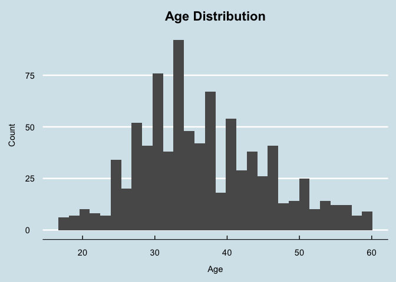

```r
ggplot(data, aes(x = Age)) +
  geom_histogram() +
  theme_economist() +
  labs(title = "Age Distribution", x = "Age", y = "Count") +
  theme(
    plot.title = element_text(hjust = 0.5, margin = margin(b = 12)),
    axis.title.x = element_text(margin = margin(t = 12)),
    axis.title.y = element_text(margin = margin(r = 12))
    )
```

There is a slight right skew to the Age feature with most of the employees being around the age of 30-40.

# Business Travel Distribution

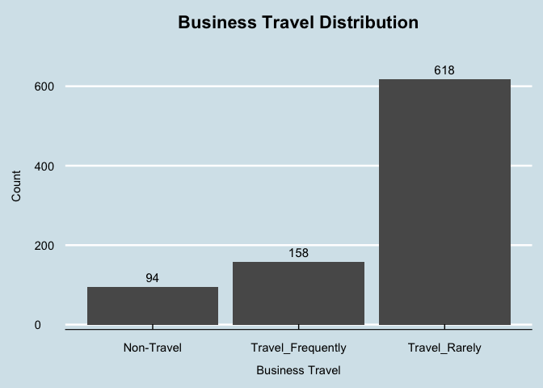

```r
ggplot(data, aes(x = BusinessTravel)) +
  geom_bar() +
  geom_text(
    stat = "count",
    aes(label = ..count..),
    vjust = -0.6, size = 4, color = "black"
  ) +
  scale_y_continuous(expand = expansion(mult = c(0.02, 0.15))) +
  theme_economist() +
  labs(title = "Business Travel Distribution", x = "Business Travel", y = "Count") +
  theme(
    plot.title = element_text(hjust = 0.5, margin = margin(b = 12)),
    axis.title.x = element_text(margin = margin(t = 12)),
    axis.title.y = element_text(margin = margin(r = 12))
    )
```

# DailyRate Distribution

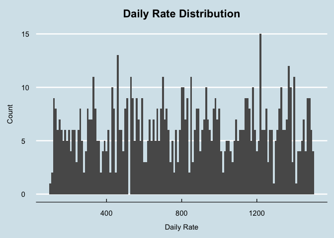

```r
ggplot(data, aes(x = DailyRate)) +
  geom_histogram(binwidth = 10) +
  theme_economist() +
  labs(title = "Daily Rate Distribution", x = "Daily Rate", y = "Count") +
  theme(
    plot.title = element_text(hjust = 0.5, margin = margin(b = 12)),
    axis.title.x = element_text(margin = margin(t = 12)),
    axis.title.y = element_text(margin = margin(r = 12))
    )
```

The Daily Rate feature appears to be uniformly distributed between 100 and 1500. No particulary useful distribution insights can be derived.

# Department Distribution

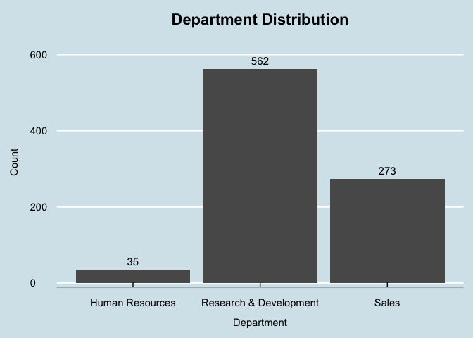

```r
ggplot(data, aes(x = Department)) +
  geom_bar() +
  geom_text(
    stat = "count",
    aes(label = ..count..),
    vjust = -0.6, size = 4, color = "black"
  ) +
  scale_y_continuous(expand = expansion(mult = c(0.02, 0.15))) +
  theme_economist() +
  labs(title = "Department Distribution", x = "Department", y = "Count") +
  theme(
    plot.title = element_text(hjust = 0.5, margin = margin(b = 12)),
    axis.title.x = element_text(margin = margin(t = 12)),
    axis.title.y = element_text(margin = margin(r = 12))
    )
```

The majority of employees work in the Research & Development department, followed by Sales and then Human Resources.

# DistanceFromHome Distribution

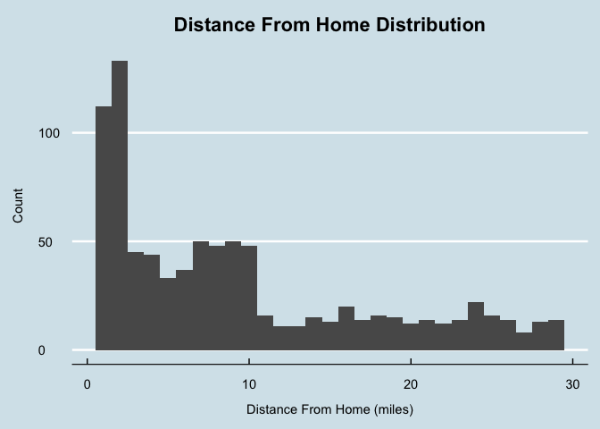

```r
ggplot(data, aes(x = DistanceFromHome)) +
  geom_histogram(binwidth = 1) +
  theme_economist() +
  labs(title = "Distance From Home Distribution", x = "Distance From Home (miles)", y = "Count") +
  theme(
    plot.title = element_text(hjust = 0.5, margin = margin(b = 12)),
    axis.title.x = element_text(margin = margin(t = 12)),
    axis.title.y = element_text(margin = margin(r = 12))
    )
```

There is a heavy concentration of employees living within 10 miles of work, with a gradual decrease in number of employees as distance increases.

# Education Distribution

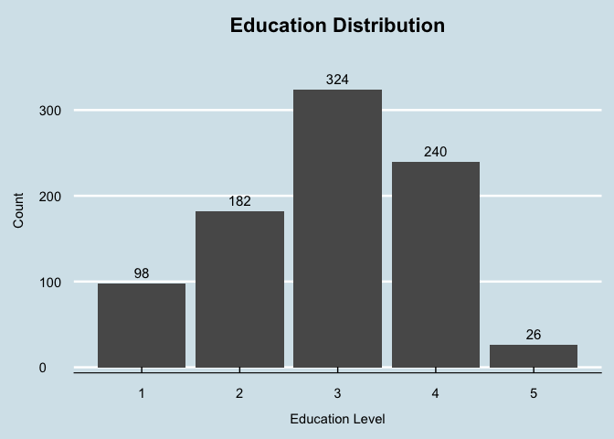

```r
ggplot(data, aes(x = Education)) +
  geom_bar() +
  geom_text(
    stat = "count",
    aes(label = ..count..),
    vjust = -0.6, size = 4, color = "black"
  ) +
  scale_y_continuous(expand = expansion(mult = c(0.02, 0.15))) +
  theme_economist() +
  labs(title = "Education Distribution", x = "Education Level", y = "Count") +
  theme(
    plot.title = element_text(hjust = 0.5, margin = margin(b = 12)),
    axis.title.x = element_text(margin = margin(t = 12)),
    axis.title.y = element_text(margin = margin(r = 12))
    )
```

Education has a normal distribution with the highest concentration of employees centering around level 3.

# EducationField Distribution

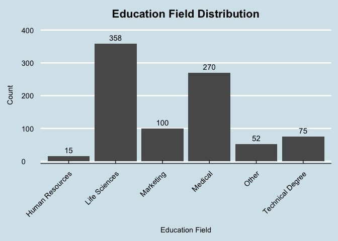

```r
ggplot(data, aes(x = EducationField)) +
  geom_bar() +
  geom_text(
    stat = "count",
    aes(label = ..count..),
    vjust = -0.6, size = 4, color = "black"
  ) +
  scale_y_continuous(expand = expansion(mult = c(0.02, 0.15))) +
  theme_economist() +
  labs(title = "Education Field Distribution", x = "Education Field", y = "Count") +
  theme(
    plot.title = element_text(hjust = 0.5, margin = margin(b = 12)),
    axis.title.x  = element_text(margin = margin(t = 12)),
    axis.title.y  = element_text(margin = margin(r = 12)),
    axis.text.x   = element_text(angle = 45, hjust = 1, vjust = 1)   # 👈 rotates labels
  )
```

The majority of employees have a background in Life Sciences, followed by Medical and then Marketing.

# EnvironmentalSatisfaction Distribution

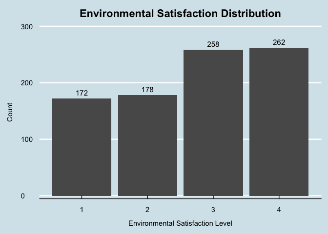

```r
ggplot(data, aes(x = EnvironmentSatisfaction)) +
  geom_bar() +
  geom_text(
    stat = "count",
    aes(label = ..count..),
    vjust = -0.6, size = 4, color = "black"
  ) +
  scale_y_continuous(expand = expansion(mult = c(0.02, 0.15))) +
  theme_economist() +
  labs(title = "Environmental Satisfaction Distribution", x = "Environmental Satisfaction Level", y = "Count") +
  theme(
    plot.title = element_text(hjust = 0.5, margin = margin(b = 12)),
    axis.title.x = element_text(margin = margin(t = 12)),
    axis.title.y = element_text(margin = margin(r = 12))
    )
```

The environmental satisfaction seems to show that more employees are satisfied than not.

# Gender Distribution

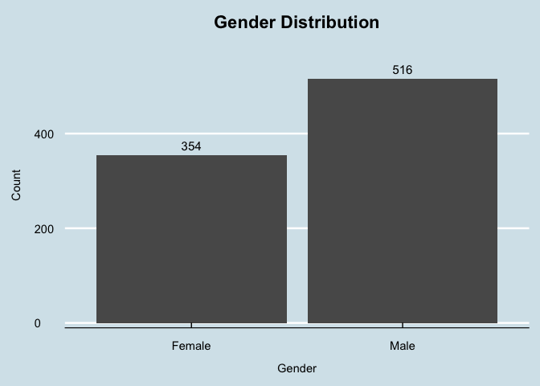

```r
ggplot(data, aes(x = Gender)) +
  geom_bar() +
  geom_text(
    stat = "count",
    aes(label = ..count..),
    vjust = -0.6, size = 4, color = "black"
  ) +
  scale_y_continuous(expand = expansion(mult = c(0.02, 0.15))) +
  theme_economist() +
  labs(title = "Gender Distribution", x = "Gender", y = "Count") +
  theme(
    plot.title = element_text(hjust = 0.5, margin = margin(b = 12)),
    axis.title.x = element_text(margin = margin(t = 12)),
    axis.title.y = element_text(margin = margin(r = 12))
    )
```

The gender distribution is showing that there are more Males than females at the company.

# HourlyRate Distribution

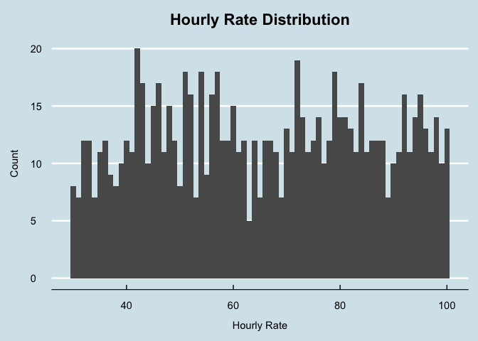

```r
ggplot(data, aes(x = HourlyRate)) +
  geom_histogram(binwidth = 1) +
  theme_economist() +
  labs(title = "Hourly Rate Distribution", x = "Hourly Rate", y = "Count") +
  theme(
    plot.title = element_text(hjust = 0.5, margin = margin(b = 12)),
    axis.title.x = element_text(margin = margin(t = 12)),
    axis.title.y = element_text(margin = margin(r = 12))
    )
```

No useful distribution insights can be derived from the Hourly Rate feature.

# JobInvolvement Distribution

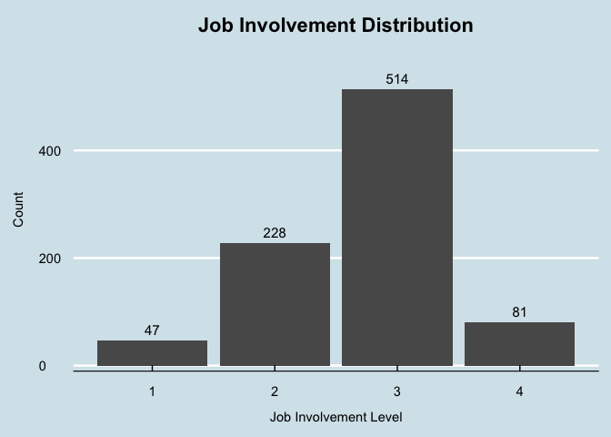

```r
ggplot(data, aes(x = JobInvolvement)) +
  geom_bar() +
  geom_text(
    stat = "count",
    aes(label = ..count..),
    vjust = -0.6, size = 4, color = "black"
  ) +
  scale_y_continuous(expand = expansion(mult = c(0.02, 0.15))) +
  theme_economist() +
  labs(title = "Job Involvement Distribution", x = "Job Involvement Level", y = "Count") +
  theme(
    plot.title = element_text(hjust = 0.5, margin = margin(b = 12)),
    axis.title.x = element_text(margin = margin(t = 12)),
    axis.title.y = element_text(margin = margin(r = 12))
    )
```

# JobLevel Distribution

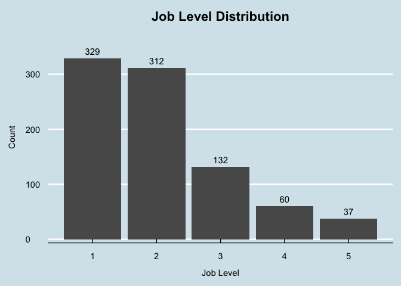

```r
ggplot(data, aes(x = JobLevel)) +
  geom_bar() +
  geom_text(
    stat = "count",
    aes(label = ..count..),
    vjust = -0.6, size = 4, color = "black"
  ) +
  scale_y_continuous(expand = expansion(mult = c(0.02, 0.15))) +
  theme_economist() +
  labs(title = "Job Level Distribution", x = "Job Level", y = "Count") +
  theme(
    plot.title = element_text(hjust = 0.5, margin = margin(b = 12)),
    axis.title.x = element_text(margin = margin(t = 12)),
    axis.title.y = element_text(margin = margin(r = 12))
    )
```

The job level distribution shows that the majority of employees are at level 1, with a decreasing number of employees as job level increases.

# MaritalStatus Distribution

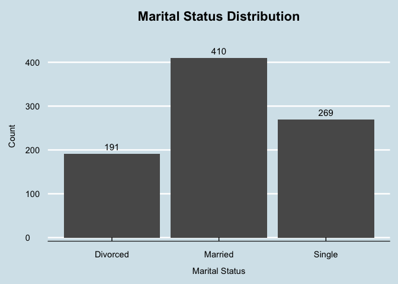

```r
ggplot(data, aes(x = MaritalStatus)) +
  geom_bar() +
  geom_text(
    stat = "count",
    aes(label = ..count..),
    vjust = -0.6, size = 4, color = "black"
  ) +
  scale_y_continuous(expand = expansion(mult = c(0.02, 0.15))) +
  theme_economist() +
  labs(title = "Marital Status Distribution", x = "Marital Status", y = "Count") +
  theme(
    plot.title = element_text(hjust = 0.5, margin = margin(b = 12)),
    axis.title.x = element_text(margin = margin(t = 12)),
    axis.title.y = element_text(margin = margin(r = 12))
    )
```

# MonthlyIncome Distribution

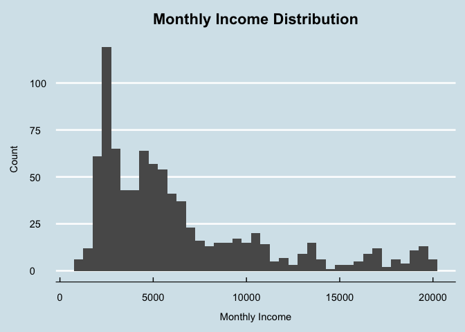

```r
ggplot(data, aes(x = MonthlyIncome)) +
  geom_histogram(binwidth = 500) +
  theme_economist() +
  labs(title = "Monthly Income Distribution", x = "Monthly Income", y = "Count") +
  theme(
    plot.title = element_text(hjust = 0.5, margin = margin(b = 12)),
    axis.title.x = element_text(margin = margin(t = 12)),
    axis.title.y = element_text(margin = margin(r = 12))
    )
```

The Monthly Income feature appears to be right skewed with most employees earning between $2000 and $8000 per month.

# NumCompaniesWorked Distribution

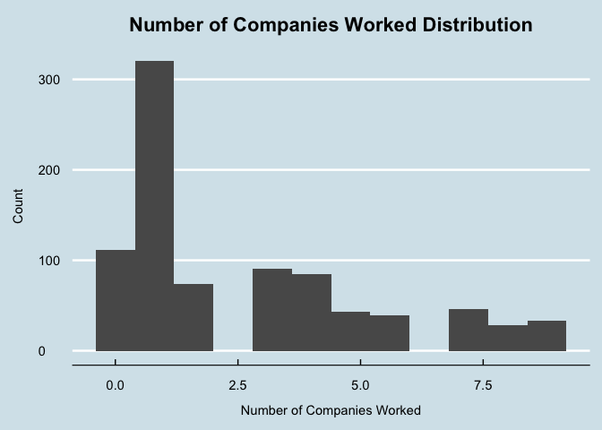

```r
ggplot(data, aes(x = NumCompaniesWorked)) +
  geom_histogram(binwidth = .8) +
  theme_economist() +
  labs(title = "Number of Companies Worked Distribution", x = "Number of Companies Worked", y = "Count") +
  theme(
    plot.title = element_text(hjust = 0.5, margin = margin(b = 12)),
    axis.title.x = element_text(margin = margin(t = 12)),
    axis.title.y = element_text(margin = margin(r = 12))
    )
```

The number of companies worked feature appears to be right skewed with most employees having worked at 1-3 companies prior to their current employment.

# OverTime Distribution

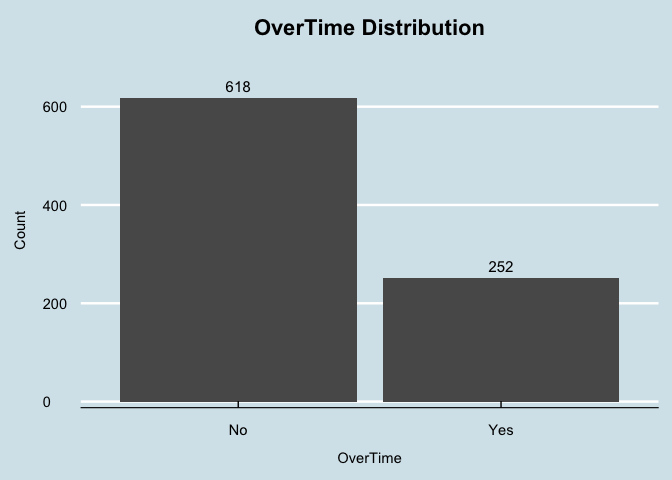

```r
ggplot(data, aes(x = OverTime)) +
  geom_bar() +
  geom_text(
    stat = "count",
    aes(label = ..count..),
    vjust = -0.6, size = 4, color = "black"
  ) +
  scale_y_continuous(expand = expansion(mult = c(0.02, 0.15))) +
  theme_economist() +
  labs(title = "OverTime Distribution", x = "OverTime", y = "Count") +
  theme(
    plot.title = element_text(hjust = 0.5, margin = margin(b = 12)),
    axis.title.x = element_text(margin = margin(t = 12)),
    axis.title.y = element_text(margin = margin(r = 12))
    )
```

Majority of employees do not work overtime.

# PercentSalaryHike Distribution

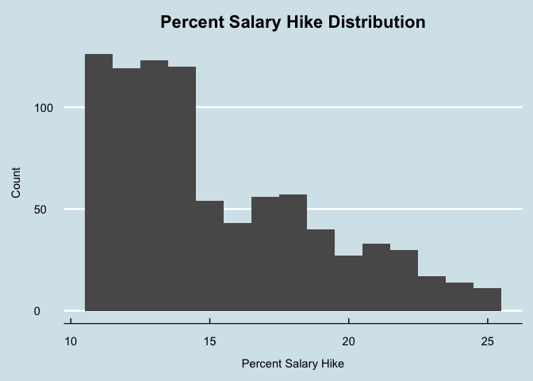

```r
ggplot(data, aes(x = PercentSalaryHike)) +
  geom_histogram(binwidth = 1) +
  theme_economist() +
  labs(title = "Percent Salary Hike Distribution", x = "Percent Salary Hike", y = "Count") +
  theme(
    plot.title = element_text(hjust = 0.5, margin = margin(b = 12)),
    axis.title.x = element_text(margin = margin(t = 12)),
    axis.title.y = element_text(margin = margin(r = 12))
    )
```

Percent Salary hike is demonstrating a heavy right skew with most employees receiving between 10-15% salary hikes.

# PerformanceRating Distribution

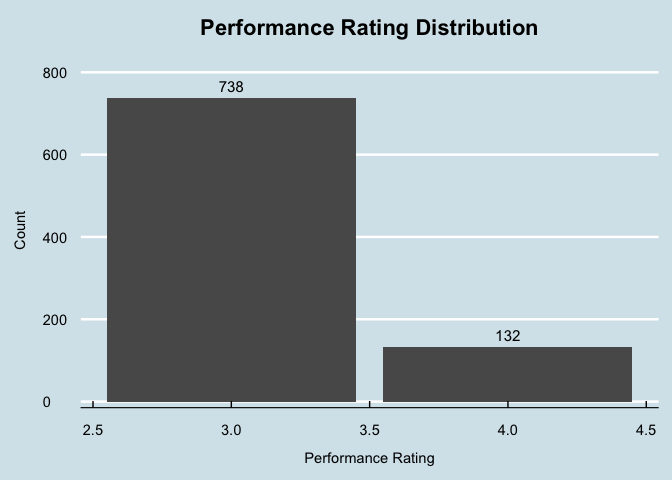

```r
ggplot(data, aes(x = PerformanceRating)) +
  geom_bar() +
  geom_text(
    stat = "count",
    aes(label = ..count..),
    vjust = -0.6, size = 4, color = "black"
  ) +
  scale_y_continuous(expand = expansion(mult = c(0.02, 0.15))) +
  theme_economist() +
  labs(title = "Performance Rating Distribution", x = "Performance Rating", y = "Count") +
  theme(
    plot.title = element_text(hjust = 0.5, margin = margin(b = 12)),
    axis.title.x = element_text(margin = margin(t = 12)),
    axis.title.y = element_text(margin = margin(r = 12))
    )
```

Majority of employees have a performance rating of 3, with very few employees receiving a rating of 4.

# RelationshipSatisfaction Distribution

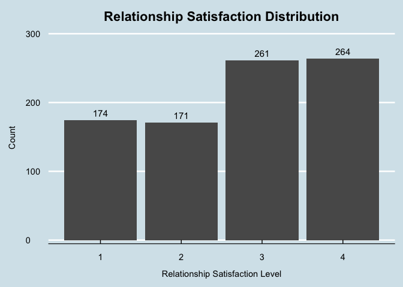

```r
ggplot(data, aes(x = RelationshipSatisfaction)) +
  geom_bar() +
  geom_text(
    stat = "count",
    aes(label = ..count..),
    vjust = -0.6, size = 4, color = "black"
  ) +
  scale_y_continuous(expand = expansion(mult = c(0.02, 0.15))) +
  theme_economist() +
  labs(title = "Relationship Satisfaction Distribution", x = "Relationship Satisfaction Level", y = "Count") +
  theme(
    plot.title = element_text(hjust = 0.5, margin = margin(b = 12)),
    axis.title.x = element_text(margin = margin(t = 12)),
    axis.title.y = element_text(margin = margin(r = 12))
    )
```

Majority of employees have a relationship satisfaction level of 3 or 4, with level 2 being the least common by a slim margin.

# StandardHours Distribution

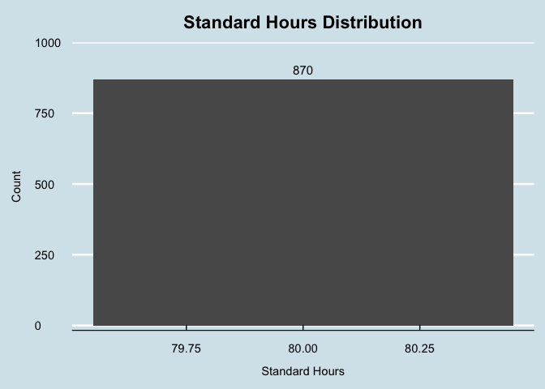

```r
ggplot(data, aes(x = StandardHours)) +
  geom_bar() +
  geom_text(
    stat = "count",
    aes(label = ..count..),
    vjust = -0.6, size = 4, color = "black"
  ) +
  scale_y_continuous(expand = expansion(mult = c(0.02, 0.15))) +
  theme_economist() +
  labs(title = "Standard Hours Distribution", x = "Standard Hours", y = "Count") +
  theme(
    plot.title = element_text(hjust = 0.5, margin = margin(b = 12)),
    axis.title.x = element_text(margin = margin(t = 12)),
    axis.title.y = element_text(margin = margin(r = 12))
    )
```

All employees have standard hours of 80.

# StockOptionLevel Distribution

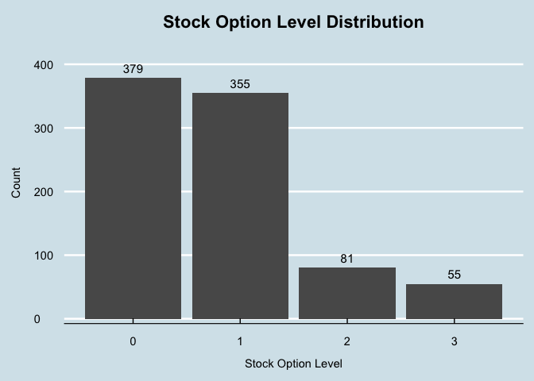

```r
ggplot(data, aes(x = StockOptionLevel)) +
  geom_bar() +
  geom_text(
    stat = "count",
    aes(label = ..count..),
    vjust = -0.6, size = 4, color = "black"
  ) +
  scale_y_continuous(expand = expansion(mult = c(0.02, 0.15))) +
  theme_economist() +
  labs(title = "Stock Option Level Distribution", x = "Stock Option Level", y = "Count") +
  theme(
    plot.title = element_text(hjust = 0.5, margin = margin(b = 12)),
    axis.title.x = element_text(margin = margin(t = 12)),
    axis.title.y = element_text(margin = margin(r = 12))
    )
```

Majority of employees have a stock option level of 0, with very few employees having a stock option level of 3.

# TotalWorkingYears Distribution

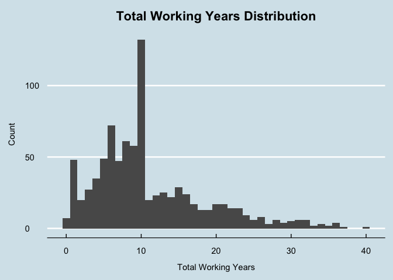

```r
ggplot(data, aes(x = TotalWorkingYears)) +
  geom_histogram(binwidth = 1) +
  theme_economist() +
  labs(title = "Total Working Years Distribution", x = "Total Working Years", y = "Count") +
  theme(
    plot.title = element_text(hjust = 0.5, margin = margin(b = 12)),
    axis.title.x = element_text(margin = margin(t = 12)),
    axis.title.y = element_text(margin = margin(r = 12))
    )
```

The Total Working Years feature appears to be right skewed with most employees having between 0-10 years of total working experience.

# TrainingTimesLastYear Distribution

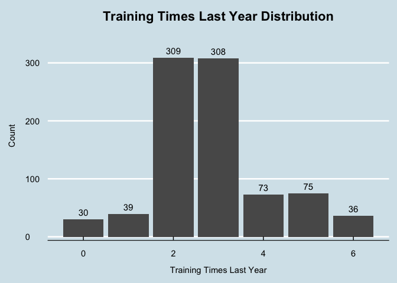

```r
ggplot(data, aes(x = TrainingTimesLastYear)) +
  geom_bar() +
  geom_text(
    stat = "count",
    aes(label = ..count..),
    vjust = -0.6, size = 4, color = "black"
  ) +
  scale_y_continuous(expand = expansion(mult = c(0.02, 0.15))) +
  theme_economist() +
  labs(title = "Training Times Last Year Distribution", x = "Training Times Last Year", y = "Count") +
  theme(
    plot.title = element_text(hjust = 0.5, margin = margin(b = 12)),
    axis.title.x = element_text(margin = margin(t = 12)),
    axis.title.y = element_text(margin = margin(r = 12))
    )
```

Majority of employees have undergone training 2-3 times in the last year.

# WorkLifeBalance Distribution

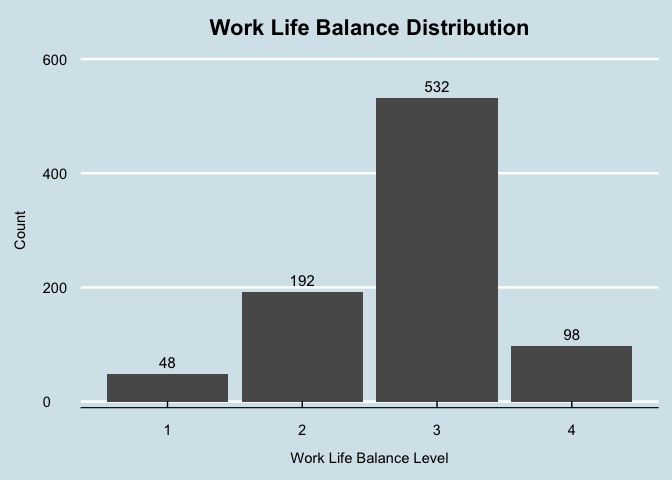

```r
ggplot(data, aes(x = WorkLifeBalance)) +
  geom_bar() +
  geom_text(
    stat = "count",
    aes(label = ..count..),
    vjust = -0.6, size = 4, color = "black"
  ) +
  scale_y_continuous(expand = expansion(mult = c(0.02, 0.15))) +
  theme_economist() +
  labs(title = "Work Life Balance Distribution", x = "Work Life Balance Level", y = "Count") +
  theme(
    plot.title = element_text(hjust = 0.5, margin = margin(b = 12)),
    axis.title.x = element_text(margin = margin(t = 12)),
    axis.title.y = element_text(margin = margin(r = 12))
    )
```

Majority of employees have a work life balance level of 3, with level 1 being the least common.

# YearsAtCompany Distribution

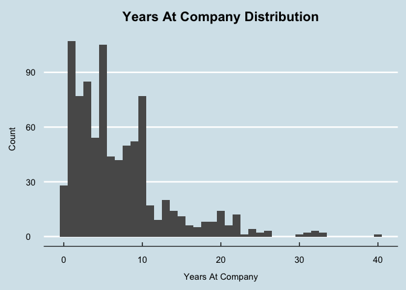

```r
ggplot(data, aes(x = YearsAtCompany)) +
  geom_histogram(binwidth = 1) +
  theme_economist() +
  labs(title = "Years At Company Distribution", x = "Years At Company", y = "Count") +
  theme(
    plot.title = element_text(hjust = 0.5, margin = margin(b = 12)),
    axis.title.x = element_text(margin = margin(t = 12)),
    axis.title.y = element_text(margin = margin(r = 12))
    )
```

The Years At Company feature appears to be right skewed with most employees having between 0-10 years at the company.

# YearsInCurrentRole Distribution

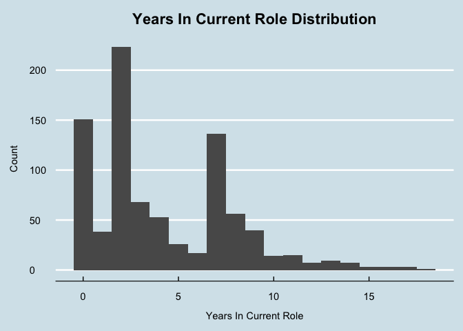

```r
ggplot(data, aes(x = YearsInCurrentRole)) +
  geom_histogram(binwidth = 1) +
  theme_economist() +
  labs(title = "Years In Current Role Distribution", x = "Years In Current Role", y = "Count") +
  theme(
    plot.title = element_text(hjust = 0.5, margin = margin(b = 12)),
    axis.title.x = element_text(margin = margin(t = 12)),
    axis.title.y = element_text(margin = margin(r = 12))
    )
```

The Years In Current Role feature appears to be right skewed with most employees having between 0-7 years in their current role.

# YearsSinceLastPromotion Distribution

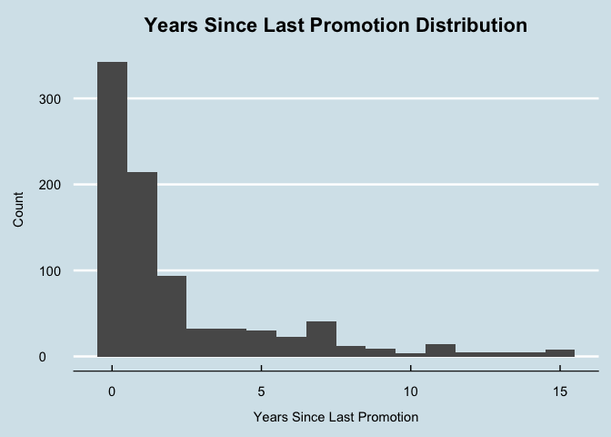

```r
ggplot(data, aes(x = YearsSinceLastPromotion)) +
  geom_histogram(binwidth = 1) +
  theme_economist() +
  labs(title = "Years Since Last Promotion Distribution", x = "Years Since Last Promotion", y = "Count") +
  theme(
    plot.title = element_text(hjust = 0.5, margin = margin(b = 12)),
    axis.title.x = element_text(margin = margin(t = 12)),
    axis.title.y = element_text(margin = margin(r = 12))
    )
```

The Years Since Last Promotion feature appears to be right skewed with most employees having between 0-3 years since their last promotion.

# YearsWithCurrManager Distribution

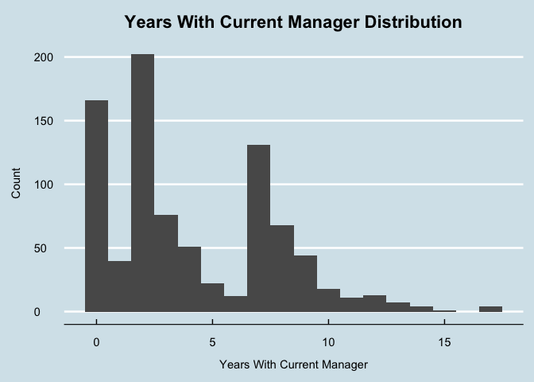

```r
ggplot(data, aes(x = YearsWithCurrManager)) +
  geom_histogram(binwidth = 1) +
  theme_economist() +
  labs(title = "Years With Current Manager Distribution", x = "Years With Current Manager", y = "Count") +
  theme(
    plot.title = element_text(hjust = 0.5, margin = margin(b = 12)),
    axis.title.x = element_text(margin = margin(t = 12)),
    axis.title.y = element_text(margin = margin(r = 12))
    )
```

The Years With Current Manager feature appears to be right skewed with most employees having between 0-7 years with their current manager.

# ———— Bivariate Analysis ————-